# Digit Pair Recognition

This was an assignement for my advanced machine learning class. The task is to build a feedforward neural network which can predict the sum modulo 10 of a pair of handwritten digit from the MNIST dataset.

The modules we will need.

```python
%matplotlib inline
import torch
import torchvision
import torch.nn as nn
from torch.utils.data import DataLoader
from torch.utils.data import Dataset
from torchvision.transforms import Compose, ToTensor, Normalize
import matplotlib.pyplot as plt
import numpy as np
import random
import seaborn as sns; sns.set_theme()
```

For faster training it's ideal to use a GPU.

```python
device = torch.device('cuda') if torch.cuda.is_available() else torch.device('cpu')
print("You train on {}".format(device))
```

```
You train on cuda
```

## Preparing data for training and model selection

PyTorch torchvision module provides some predesigned datasets. Like the MNIST dataset, that we are going to use (https://pytorch.org/vision/0.8/_modules/torchvision/datasets/mnist.html#MNIST). Here is the code to download the dataset.

```python
!wget www.di.ens.fr/~lelarge/MNIST.tar.gz
!tar -zxvf MNIST.tar.gz
```

```
--2021-06-20 10:25:51--  http://www.di.ens.fr/~lelarge/MNIST.tar.gz
Resolving www.di.ens.fr (www.di.ens.fr)... 129.199.99.14
Connecting to www.di.ens.fr (www.di.ens.fr)|129.199.99.14|:80... connected.
HTTP request sent, awaiting response... 302 Found
Location: https://www.di.ens.fr/~lelarge/MNIST.tar.gz [following]
--2021-06-20 10:25:51--  https://www.di.ens.fr/~lelarge/MNIST.tar.gz
Connecting to www.di.ens.fr (www.di.ens.fr)|129.199.99.14|:443... connected.
HTTP request sent, awaiting response... 200 OK
Length: unspecified [application/x-gzip]
Saving to: ‘MNIST.tar.gz’

MNIST.tar.gz            [             <=>    ]  33.20M  10.5MB/s    in 3.1s

2021-06-20 10:25:55 (10.5 MB/s) - ‘MNIST.tar.gz’ saved [34813078]

MNIST/
MNIST/raw/
MNIST/raw/train-labels-idx1-ubyte
MNIST/raw/t10k-labels-idx1-ubyte.gz
MNIST/raw/t10k-labels-idx1-ubyte
MNIST/raw/t10k-images-idx3-ubyte.gz
MNIST/raw/train-images-idx3-ubyte
MNIST/raw/train-labels-idx1-ubyte.gz
MNIST/raw/t10k-images-idx3-ubyte
MNIST/raw/train-images-idx3-ubyte.gz
MNIST/processed/
MNIST/processed/training.pt
MNIST/processed/test.pt
```

### MnistPairs dataset

Time to implement the dataset class. We will make our own dataset where the digits are order once in a normal order and once reversed, so we'll have a 'left' and a 'right' ordered dataset.

```python
class MnistPairs(Dataset):
    """Dataset with Mnist pairs."""

    def __init__(self, root, train, download, transform=None, order='right', return_original_labels=False):
        """
        Args:
            root (string): Directory to store the downloaded MNIST dataset.
            train (bool): If True, use the training part of the MNIST dataset.
            download(bool): If True, will download the dataset, if it is not in the root folder.
            transform (callable, optional): Optional transform to be applied on a sample.
            order (str): Indicates which ordering of digits to use, ['right', 'left'].
            return_original_labels (bool): Indicates if it is needed to return the original MNIST labels.
        """

        assert order in ['right', 'left'], "Got unexpected order argument. Expected one of ['right', 'left']"
        self.order = order

        self.return_original_labels = return_original_labels

        self.mnist_dataset = torchvision.datasets.MNIST(
            root=root,
            train=train,
            download=download,
            transform=transform)


    def __len__(self):
        # MnistPairs should be half the size of the MNIST dataset
        return len(self.mnist_dataset) // 2


    def __getitem__(self, idx):
        # If MNIST is [a, b, c, d], then MnistPairs
        # with the 'right' order are [[a, b], [c, d]],
        # and [[b, a], [d, c]] for the 'left' order.
        # The label is mod 10 sum of the MNIST labels.

        #the indexes
        if self.order == "right":
          idx1 = 2 * idx
          idx2 = 2 * idx + 1
        elif self.order == "left":
          idx1 = 2 * idx + 1
          idx2 = 2 * idx
        else:
          raise ValueError("Neither left or right order!")

        #assign
        (first_image, first_label) = self.mnist_dataset[idx1]
        (second_image, second_label) = self.mnist_dataset[idx2]
        label = (first_label + second_label) % 10

        #join images
        joined_image = torch.cat((first_image, second_image), 2)

        if self.return_original_labels:
            return joined_image, label, first_label, second_label

        return joined_image, label
```

So we can now load the dataset.

```python
#transforms converts images to tensor
transformer = Compose([ToTensor(), Normalize(mean=(0.5,), std=(0.5,))])

#training data
left_train = MnistPairs(root="", train=True, download=False, order="right", transform=transformer, return_original_labels=True)
right_train = MnistPairs(root="", train=True, download=False, order="left", transform=transformer, return_original_labels=True)

#test data
left_test = MnistPairs(root="", train=False, download=False, order="right", transform=transformer, return_original_labels=True)
right_test = MnistPairs(root="", train=False, download=False, order="left", transform=transformer, return_original_labels=True)
```

Let's look at an example from the left and right training dataset.

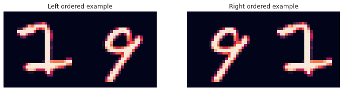

```python
fig, (ax1, ax2) = plt.subplots(1, 2, figsize=(12, 6))

#get random example
i = random.randrange(len(left_train))
left_train_example = left_train[i][0].permute(1,2,0).reshape((28, 56)).numpy()
right_train_example = right_train[i][0].permute(1,2,0).reshape((28, 56)).numpy()

#left example
ax1.title.set_text("Left ordered example")
ax1.imshow(left_train_example)

#right example
ax2.title.set_text("Right ordered example")
ax2.imshow(right_train_example)

#show
ax1.set_axis_off(), ax2.set_axis_off()
plt.show()
```

Now we can split the data, 90% for training and 10% for validation. We define these functions so we can use it later...

```python
def split_dataset(dataset):
  #calculate size
  train_size = int(0.9 * len(dataset))
  valid_size = len(dataset) - train_size

  #split data
  train_dataset, valid_dataset = torch.utils.data.random_split(dataset, [train_size, valid_size])

  return (train_dataset, valid_dataset)

def join_dataset(left_dataset, right_dataset):
  #join left and right set
  dataset = torch.utils.data.ConcatDataset([left_dataset, right_dataset])

  return dataset
```

```python
#split the data to training and validation
left_train, left_valid = split_dataset(left_train)
right_train, right_valid = split_dataset(right_train)

#join left and right sets
train_dataset = join_dataset(left_train, right_train)
valid_dataset = join_dataset(left_valid, right_valid)
test_dataset = join_dataset(left_test, right_test)
```

### Label and Pair Distribution

So we now want to look at the distribution of the labels.

```python
def calculate_distribution_of_labels(dataset):
    #get the count
    s = 0
    count = np.zeros(10)
    for data in dataset:
      s += 1
      count[data[1]] += 1

    #we want a pourcentage
    pourcentage = 1/s * count

    return pourcentage

def show_distribution_of_labels(name, dataset):
    #get the data
    label = [str(i) for i in range(10)]
    distribution = calculate_distribution_of_labels(dataset)

    #show the data
    fig, ax = plt.subplots()
    fig.suptitle(name)
    ax.set_ylim((0, 0.2))
    ax.bar(label, distribution)
    ax.plot()
```

Let's visualize the distribution of the labels in the training, validation and testing sets.

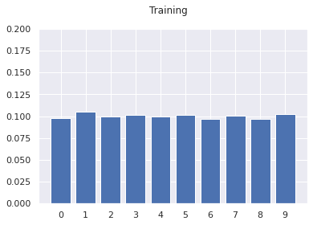

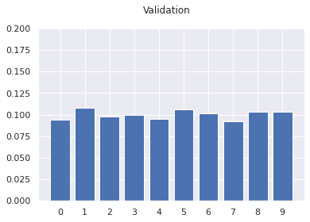

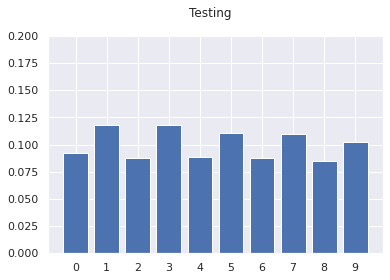

```python
show_distribution_of_labels("Training", train_dataset)
show_distribution_of_labels("Validation", valid_dataset)
show_distribution_of_labels("Testing", test_dataset)
```

We will use a 2d heatmap to see the occurrence of each pair label.

```python
def calculate_distribution_of_pairs(dataset):
  #count the occurences
  s = 0
  count = np.zeros((10, 10))
  for data in dataset:
    x = data[2]
    y = data[3]
    s += 1
    count[y][x] += 1

  #we want a pourcentage
  pourcentage = 1/s * count

  return pourcentage

def show_distribution_of_pairs(name, dataset):
  #get the data
  distribution = calculate_distribution_of_pairs(dataset)

  #show the data
  fig, ax = plt.subplots()
  sns.heatmap(distribution, ax=ax, vmin=0.0, vmax=0.02)
  ax.set(title=name)
```

Let's visualize the distribution of the pairs in the training, validation and testing sets.

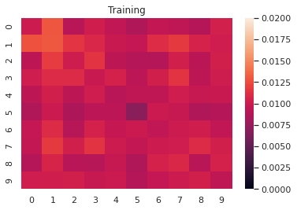

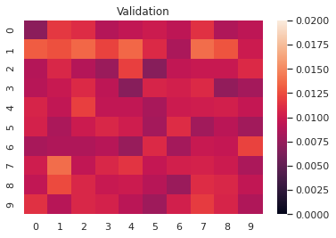

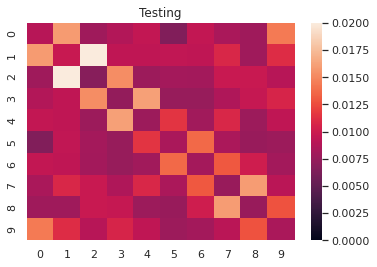

```python
show_distribution_of_pairs("Training", train_dataset)
show_distribution_of_pairs("Validation", valid_dataset)
show_distribution_of_pairs("Testing", test_dataset)
```

If the distribution of the labels in the test set differs from the one in the training set, we should expect a different performance of the model on the test set.

## Designing training settings

let's define 3 models to test with different size, loss function, optimizers and learning rate...

```python
class Net(nn.Module):
  def __init__(self, network, loss_function):
    super(Net, self).__init__()
    self.main = network
    self.loss_function = loss_function

  def forward(self, x):
    out = x.view(x.size(0), 28*56)
    out = self.main(out)
    return out
```

The first model

```python
network1  = nn.Sequential(nn.Linear(28*56, 250), nn.ReLU(),
                         nn.Linear(250, 150), nn.ReLU(),
                         nn.Linear(150, 10))
loss_function = nn.CrossEntropyLoss()
model1 = Net(network1, loss_function)
model1.optimizer = torch.optim.SGD(model1.parameters(), lr=0.02)
model1.to(device)
```

```
Net(
  (main): Sequential(
    (0): Linear(in_features=1568, out_features=250, bias=True)
    (1): ReLU()
    (2): Linear(in_features=250, out_features=150, bias=True)
    (3): ReLU()
    (4): Linear(in_features=150, out_features=10, bias=True)
  )
  (loss_function): CrossEntropyLoss()
)
```

The second model

```python
network2  = nn.Sequential(nn.Linear(28*56, 500), nn.ReLU(),
                         nn.Linear(500, 10))
loss_function = nn.CrossEntropyLoss()
model2 = Net(network2, loss_function)
model2.optimizer = torch.optim.Adam(model2.parameters(), lr=0.0003, betas=(0.9, 0.999), eps=1e-08, weight_decay=0, amsgrad=False)
model2.to(device)
```

```
Net(
  (main): Sequential(
    (0): Linear(in_features=1568, out_features=500, bias=True)
    (1): ReLU()
    (2): Linear(in_features=500, out_features=10, bias=True)
  )
  (loss_function): CrossEntropyLoss()
)
```

The third model

```python
network3  = nn.Sequential(nn.Linear(28*56, 100), nn.PReLU(),
                         nn.Linear(100, 100), nn.PReLU(),
                         nn.Linear(100, 10))
loss_function = nn.CrossEntropyLoss()
model3 = Net(network3, loss_function)
model3.optimizer = torch.optim.SGD(model3.parameters(), lr=0.03)
model3.to(device)
```

```
Net(
  (main): Sequential(
    (0): Linear(in_features=1568, out_features=100, bias=True)
    (1): PReLU(num_parameters=1)
    (2): Linear(in_features=100, out_features=100, bias=True)
    (3): PReLU(num_parameters=1)
    (4): Linear(in_features=100, out_features=10, bias=True)
  )
  (loss_function): CrossEntropyLoss()
)
```

Let us also define the metric we are going to use for the assesment of the model. We will simply use the accuracy of the model.

```python
def get_accuracy(labels, predictions):
    # Return the accuracy of predictions, i.e. the part of cases
    # where the corresponding prediction matches the label.
    accuracy = (predictions == labels).sum().item() / len(labels)
    return accuracy
```

Write the evaluation code.

```python
def evaluate_model(model, valid_dataset):
    model.eval() #set model to evaluation mode
    accuracy_sum = 0
    loss_sum = 0
    c = 0

    with torch.no_grad():
        for images, labels, labels1, labels2 in valid_dataset:

            images = images.to(device)
            labels = labels.to(device)

            #predict and check prediction
            pred = model(images)
            pred_label = pred.argmax(dim=1)

            #get metrics
            accuracy_sum += get_accuracy(labels, pred_label)
            loss_sum += model.loss_function(pred, labels)
            c += 1

    #average out
    avg_loss = loss_sum / c
    avg_accuracy = accuracy_sum / c

    print('Validation: average loss: {:.4f}, average accuracy: {:.3f}'.format(avg_loss, avg_accuracy))
    return avg_loss, avg_accuracy
```

Write the training code.

```python
def train_model(model, train_loader):
    model.train() #set model to training mode
    accuracy_sum = 0
    loss_sum = 0
    c = 0

    for iteration, (images, labels, labels1, labels2) in enumerate(train_loader):

      images = images.to(device)
      labels = labels.to(device)

      #make prediction
      model.optimizer.zero_grad()
      pred = model(images)
      pred_label = pred.argmax(dim=1)
      acccuracy = get_accuracy(labels, pred_label)

      #backpropagate
      loss = model.loss_function(pred, labels)
      loss.backward()
      model.optimizer.step()

      loss_sum += loss
      accuracy_sum += acccuracy
      c += 1

    #average
    avg_loss = loss_sum / c
    avg_accuracy = accuracy_sum / c

    print('Training: average loss: {:.4f}, average accuracy: {:.3f}'.format(avg_loss, avg_accuracy))
    return avg_loss, avg_accuracy
```

The main loop: for each epoch we train on the training dataset and then evaluates the model with the validation set. We will keep track of the performance

```python
def run(model, train_loader, valid_dataset, num_epochs):
    train_losses = []
    valid_losses = []
    train_accuracies = []
    valid_accuracies = []

    print("__Training__\n")

    for epoch in range(num_epochs):
        print("EPOCH " + str(epoch))

        #train
        train_loss, train_accuracy = train_model(model, train_loader)

        #validate
        valid_loss, valid_accuracy = evaluate_model(model, valid_dataset)

        #append to lists
        train_losses.append(train_loss)
        valid_losses.append(valid_loss)
        train_accuracies.append(train_accuracy)
        valid_accuracies.append(valid_accuracy)

    print("__Finished__\n")

    return train_losses, valid_losses, train_accuracies, valid_accuracies
```

We use this function to plot the losses and accuracies on both testing and validation.

```python
def plot_progress(names, train_losses, valid_losses, train_accuracies, valid_accuracies):
    fig, axs = plt.subplots(2, 2, figsize=(10, 10))

    axs[0][0].set_title("Training Loss")
    axs[1][0].set_title("Validation Loss")

    axs[0][1].set_title("Training Accuracy")
    axs[1][1].set_title("Validation Accuracy")

    for i in range(len(names)):
      axs[0][0].plot(train_losses[i], label=names[i])
      axs[1][0].plot(valid_losses[i], label=names[i])
      axs[0][1].plot(train_accuracies[i], label=names[i])
      axs[1][1].plot(valid_accuracies[i], label=names[i])

    axs[0][0].legend(), axs[1][0].legend()
    axs[0][1].legend(), axs[1][1].legend()
```

## Training on the training 'right' set.

So the idea is to train the models only on 'right' ordered dataset but validate in on the joined validation set.

```python
right_train_loader = DataLoader(right_train, batch_size=100, shuffle=True)
valid_loader = DataLoader(valid_dataset, shuffle=True)

epoch = 15
```

We are training the models on the 'right' training.

```python
train_loss1, valid_loss1, train_acc1, valid_acc1 = run(model1, right_train_loader, valid_loader, epoch)
```

```python
train_loss2, valid_loss2, train_acc2, valid_acc2 = run(model2, right_train_loader, valid_loader, epoch)
```

```python
train_loss3, valid_loss3, train_acc3, valid_acc3 = run(model3, right_train_loader, valid_loader, epoch)
```

Now let's look at the training loss, validation loss and the accuracy on the validation set.

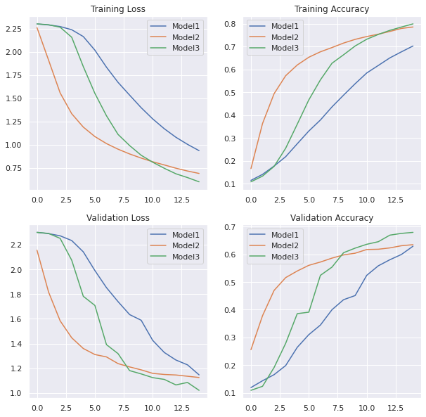

```python
#show stats
names = ["Model1", "Model2", "Model3"]
train_loss = [train_loss1, train_loss2, train_loss3]
valid_loss = [valid_loss1, valid_loss2, valid_loss3]
train_acc = [train_acc1, train_acc2, train_acc3]
valid_acc = [valid_acc1, valid_acc2, valid_acc3]

plot_progress(names, train_loss, valid_loss, train_acc, valid_acc)
plt.show()
```

The first model seems to converge the slowest but improves in a steady rythm. The second model seems to converge the fastest and does not jump around like the third model. It's seems like it's a good balance between learning rate and network size, so I would choose the second model.

## Train on concatenated training set.

```python
#loader
train_loader = DataLoader(train_dataset, batch_size=100, shuffle=True)
valid_loader = DataLoader(valid_dataset, shuffle=True)
test_loader = DataLoader(test_dataset)

epoch = 15
```

Train the models on concatenated training set.

```python
train_loss1, valid_loss1, train_acc1, valid_acc1 = run(model1, train_loader, valid_loader, epoch)
```

```python
train_losses2, valid_loss2, train_acc2, valid_acc2 = run(model2, train_loader, valid_loader, epoch)
```

```python
train_losses3, valid_loss3, train_acc3, valid_acc3 = run(model3, train_loader, valid_loader, epoch)
```

Now let's look at the training loss, validation loss and the accuracy on the validation set.

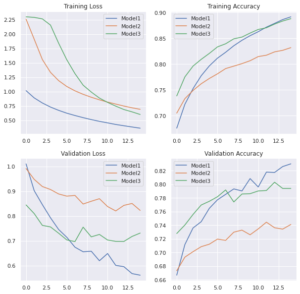

```python
#show stats
names = ["Model1", "Model2", "Model3"]
train_loss = [train_loss1, train_loss2, train_loss3]
valid_loss = [valid_loss1, valid_loss2, valid_loss3]
train_acc = [train_acc1, train_acc2, train_acc3]
valid_acc = [valid_acc1, valid_acc2, valid_acc3]

plot_progress(names, train_loss, valid_loss, train_acc, valid_acc)
plt.show()
```

We see a gap between the testing and validation loss and accuracy. The models seems to overfit overall. Interestingly the model 1 has reached higher performance than the others.

## Evaluation

```python
def getPairAccuracy(model, dataset):
  model.eval() #set model to evaluation mode
  count = np.zeros((10, 10)) #to count true
  total = np.zeros((10, 10)) #to count occurence

  with torch.no_grad():
        for images, labels, labels1, labels2 in dataset:

            images = images.to(device)
            labels = labels.to(device)

            pred = model(images)
            pred_label = pred.argmax(dim=1)

            for i in range(len(labels)):
              x = labels1[i]
              y = labels2[i]
              total[y][x] += 1
              if (labels[i] == pred_label[i]):
                  count[y][x] += 1

  D1 = np.sum(count) / np.sum(total) #the accuracy in 1D
  D2 = np.divide(count, total) #the accuracy in 2D

  return D1, D2
```

```python
accuracy, distribution = getPairAccuracy(model3, test_loader)
print('Validation accuracy: {:.3f}%, Testing accuracy: {:.3f}%'.format(valid_acc3[-1], accuracy))
```

```
Validation accuracy: 0.794%, Testing accuracy: 0.801%
```

## Visualizations

```python
def error(prediction, label):
  a = prediction.cpu().numpy()[0]
  l = label.cpu().item()

  b = [0]*10
  b[l] = 1

  d = np.linalg.norm(a - b)

  return d
```

```python
def get_worst_and_best(model, dataset, n):
    model.eval() #set model to evaluation mode
    successes = [] #list of best pred (image, label)
    failures = [] #list of worst pred (image, label)

    with torch.no_grad():
        for images, labels, labels1, labels2 in dataset:

            images = images.to(device)
            labels = labels.to(device)

            pred = model(images)
            pred_label = pred.argmax(dim=1)

            d = error(pred, labels)

            if pred_label != labels:
              failure = (images, d, pred_label.item(), labels.item())
              failures.append(failure)
            else:
              success = (images, d, pred_label.item(), labels.item())
              successes.append(success)

    successes.sort(key=lambda x: x[1], reverse=True)
    successes = successes[:n]

    failures.sort(key=lambda x: x[1], reverse=True)
    failures = failures[:n]

    return successes, failures
```

```python
n = 5 #n example each of success and failure
successes, failures = get_worst_and_best(model3, test_loader, n)
```

Let's visualize the failures on the left, and the successes on the right.

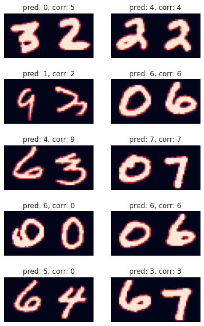

```python
fig, axs = plt.subplots(n, 2)
fig.set_figheight(10)

for i in range(n):
  #show failure on left
  img = failures[i][0].permute(2,3, 0, 1).reshape((28, 56)).cpu().numpy()
  label = "pred: " + str(failures[i][2]) + ", corr: " + str(failures[i][3])
  axs[i, 0].imshow(img)
  axs[i, 0].axis('off')
  axs[i, 0].set_title(str(label))

  #show failure on right
  img = successes[i][0].permute(2,3, 0, 1).reshape((28, 56)).cpu().numpy()
  label = "pred: " + str(successes[i][2]) + ", corr: " + str(successes[i][3])
  axs[i, 1].imshow(img)
  axs[i, 1].axis('off')
  axs[i, 1].set_title(str(label))

plt.show()
```

The more the detail the better the model performs. Some example even a human would predict wrong, which is also the fault of the dataset which can have bad examples.

Let's now look on a 2d Heatmap which pairs the model performs the best. The x axsis shows the first label, the y axsis shows the second label and the color shows the corresponding accuracy on that pair.

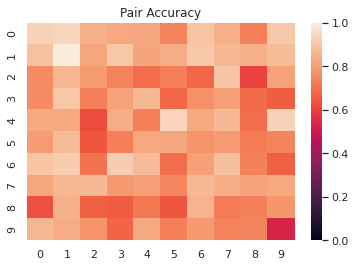

```python
def showPairAccuracy(distribution):
  #show the data
  fig, ax = plt.subplots()
  sns.heatmap(distribution, ax=ax, vmin=0.0, vmax=1.0)
  ax.set(title="Pair Accuracy")

showPairAccuracy(distribution)
```

If you look at the pair representation we calculated earlier you can actually see that the model doesn't perform as well on the label pairs which are underrepresented. The model also seems to have trouble mostly with the number 2, 3, 5, 8. But is it really surprising? Those can look very alike, and can even be hard for humans to make the difference.